# Environmental Factor’s effect on Redlined Communities

Annie Adams

Dec 10, 2023

## Background

Present-day environmental justice may reflect legacies of injustice in the past. The United States has a long history of racial segregation which is still visible. During the 1930’s the Home Owners’ Loan Corporation (HOLC), as part of the New Deal, rated neighborhoods based on their perceived safety for real estate investment. Their ranking system, (A (green), B (blue), C (yellow), D (red)) was then used to block access to loans for home ownership. Colloquially known as “redlining”, this practice has had widely-documented consequences not only for community wealth, but also health.[^1] Redlined neighborhoods have less greenery[^2] and are hotter than other neighborhoods.[^3]

A recent study found that redlining has not only affected the environments communities are exposed to, it has also shaped our observations of biodiversity.

## Overview

This repo will explore both the relationships between census groups/HOLC groups with environmental factors. We will first look at the relationship between census groups and environmental factors. Using historical redlining data, we will then explore similar environmental factors as we did with census groups, but with HOLC grades instead. We will see if we can find any noticeable differences amongst different HOLC grades to see if redlining still plays an effect in these neighborhoods. We will explore these differences through both visual and numerical analysis.

## Datasets:

#### EJScreen

We will be working with data from the United States Environmental Protection Agency’s EJScreen: Environmental Justice Screening and Mapping Tool.

EJScreen provides on environmental and demographic information for the US at the Census tract and [block group](https://en.wikipedia.org/wiki/Census_block_group) levels.

#### Biodiversity observation data

The [Global Biodiversity Information Facility](https://www.gbif.org/) is the largest aggregator of biodiversity observations in the world. Observations typically include a location and date that a species was observed.We will be working observations of birds from 2021 onward.

#### Inequality Maps

A team of researchers, led by the [Digital Scholarship Lab](https://dsl.richmond.edu/) at the University of Richmond have digitized maps and information from the HOLC as part of the [Mapping Inequality](https://dsl.richmond.edu/panorama/redlining/#loc=5/39.1/-94.58) project.

We will be working with maps of HOLC grade designations for Los Angeles. Information on the data can be found [here](https://dsl.richmond.edu/panorama/redlining/#loc=5/39.1/-94.58&text=downloads).[^4]

## Analysis

### Load Necessary packages and data

```r
library(terra)
library(dplyr)
library(spData)
library(spDataLarge)
library(tmap)
library(geodata)
library(tidyverse)
library(here)
library(sf)
library(gt)
library(kableExtra)
```

Read in EJScreen data and filter to Los Angeles County

```r
ejscreen <- st_read("../data/EJSCREEN_2023_BG_StatePct_with_AS_CNMI_GU_VI.gdb/")

la_data <- ejscreen %>% filter(CNTY_NAME == "Los Angeles County") # filter data to LA
```

Import redlining information for Los Angeles.

```r
LA_redlining <- st_read("https://dsl.richmond.edu/panorama/redlining/static/citiesData/CALosAngeles1939/geojson.json") %>%
  st_make_valid()
```

Read in bird data from Global Biodiversity Information Facility.

```r
bird <- st_read("../data/gbif-birds-LA")
```

### Create wastewater map across census groups

Different environmental factors affect different censuses in disproportionate ways. To visualize this, we will map wastewater discharge.To see the upper values for this variables, we will select census block groups that are greater than the 95th percentile.

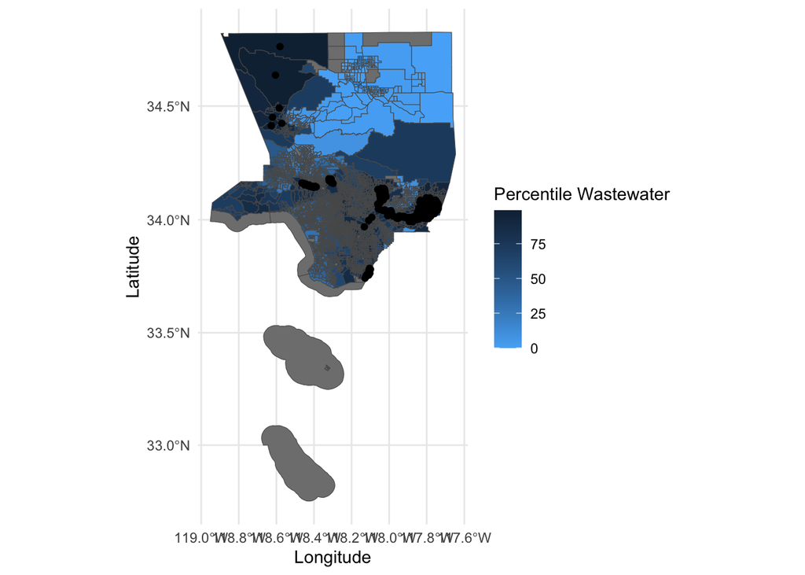

```r
wastewater_95_perc <- la_data %>% filter(P_PWDIS > 95)
#la_centroids <- st_centroid(la_data)
la_over95_centroids <- st_centroid(wastewater_95_perc)

wastewater_map <-ggplot()+
  geom_sf(data = la_data, aes(fill =P_PWDIS)  )+
  geom_sf(data = la_over95_centroids, aes(fill = P_PWDIS))+
  labs(fill='Percentile Wastewater', x = "Longitude", y = "Latitude")+
  scale_fill_gradient(low = "#56B1F7", high = "#132B43")+
  theme_minimal()



wastewater_map
```

This map allows us to visualize which areas of LA county have a higher percent of wastewater. Gray areas are areas in which no wastewater percentile was reported.

#### Low income percentage in census groups

Let’s now look more closely at other relationships amongst block groups and environmental factors. We will start by finding the percent of census block groups where less than 5% of the population is considered low income.

```r
less_5_inc <- la_data %>% filter(LOWINCPCT <.05)
perc_below5_income <- round(length(less_5_inc$LOWINCPCT)/ length(la_data$LOWINCPCT), 3) * 100
print(paste0("The percent of census block groups where less than 5% of the population is considered low income is ", perc_below5_income, "%."))
```

```
## [1] "The percent of census block groups where less than 5% of the population is considered low income is 6.1%."
```

6.1% is a pretty small number when discussing percentages not considered low income. This means that in approximately 94% of census groups in LA, the population considered low income is greater than 5%.

#### Census groups and air quality experiences

We will continue to look at percentages amongst block groups for some different environmental factors, specifically what percent of census block groups that are both above the 80th percentile for PM 2.5 as well as the 80th percentile for the Superfund proximity ( a superfund is an abandoned hazardous waste site). These combination of different variables allow us to dive specifically into how variables related to air quality effect different census groups.

```r
above_80_pm25_pnpl <- la_data %>% filter(P_PM25 >80, P_PNPL>80)
perc_above80_pm25_pnpl <- round(length(above_80_pm25_pnpl$P_PM25)/ length(la_data$P_PM25), 3) * 100
print(paste0("The percent of census block groups above the 80th percentile for both PM 2.5 and Superfund proximity is ", perc_above80_pm25_pnpl, "%."))
```

```
## [1] "The percent of census block groups above the 80th percentile for both PM 2.5 and Superfund proximity is 17.4%."
```

#### Mapping Redlined Neighborhoods by HOLC grades

We will now utilize the LA Redlining data we loaded in. Let’s start with some exploratory analysis to get a better idea of what our data looks like. We will simply create a map of the different HOLC grades in LA County.

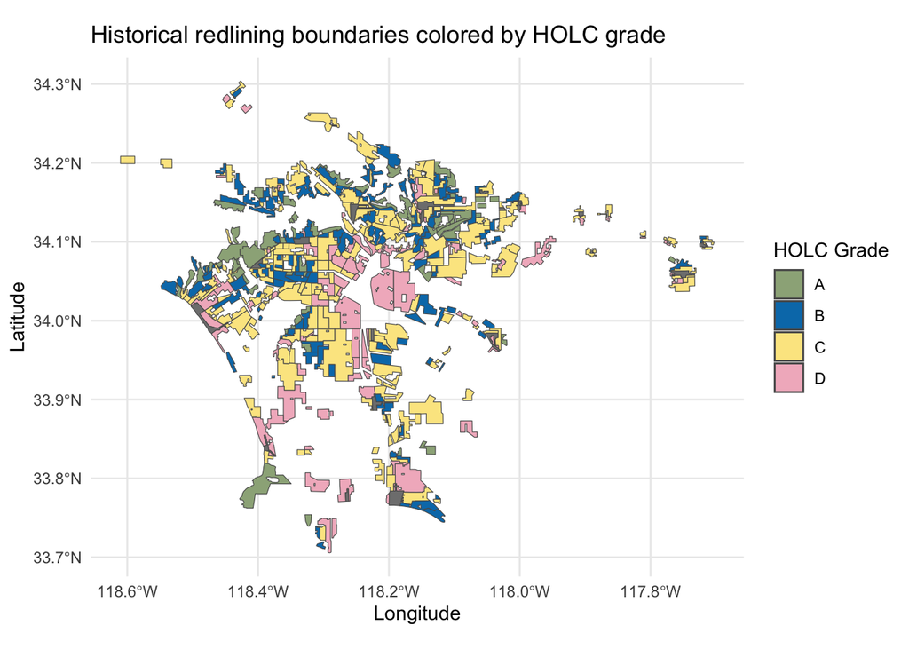

```r
holc_colors <- c(
  "A" = "#9CAF88",
  "B" = "#007BB8",
  "C" = "#FBE790",
  "D" = "#F2B8C6"
)


redlining_map <-ggplot()+
  #geom_sf(data = la_data, fill = NA)+
  geom_sf(data = LA_redlining, aes(fill = grade))+
   scale_fill_manual(values = holc_colors)+
  labs(fill='HOLC Grade', x = "Longitude", y = "Latitude", title = "Historical redlining boundaries colored by HOLC grade") +
  theme_minimal()
redlining_map
```

```r
ggsave(filename = "../Results/HOLC_grade_map.png", plot = last_plot())
```

#### Census groups within HOLC grades

Now that we have visualized the geographical relationships of different HOLC grades in LA county, lets look a bit more into the specifics of census groups within the different HOLC grades. We will start by determining how many different census groups are within the four different HOLC grades.

```r
# Check crs for both datasets
st_crs(LA_redlining) == st_crs(la_data)
la_data <- st_transform(la_data, crs = 4326) # change la data to have crs 4326


cen_holc<- st_join(x = la_data, y = LA_redlining, join = st_within, left = FALSE) # join la data and redlining data using st_within to find where areas with HOLC grades
census_group_HOLC <-nrow(cen_holc) # find number of census block groups that fall within HOLC grades

print(paste0("There are ",census_group_HOLC, " census block groups that fall within HOLC grade areas." ))
```

[output not shown]

#### Environmental experiences within HOLC grades

We looked into how different environmental factors impact census groups, but now lets do the same with HOLC grades instead of census groups. Doing so will allow us to see if different environmental factors disproportionately affect different HOLC grades. We will look at four different environmental factors: average percent low income, average percent of PM 2.5 present, average percentile for low life expectancy, and average percentile for air toxics cancer risk.

In order to do this, we need to start by joining our redlined data with the EJ screen data from LA.

```r
la_data <- st_transform(la_data, crs = 4326) # change la data to have crs 4326
redline_ej_join<- st_join(LA_redlining, la_data) # join redline and la data
```

```r
redline_ej_join_test <- redline_ej_join %>%
  group_by(grade) %>%
  summarise( #create average variable for each of the four catergories we are looking into, drop NAs and calculate mean
    "Average low income percent" = mean(LOWINCPCT, na.rm = TRUE),
    "Average percent PM 25" = mean(P_PM25, na.rm = TRUE),
    "Average percentile for low life expectancy"  = mean(LIFEEXPPCT, na.rm = TRUE),
    "Average percentile for air toxics cancer risk" = mean(P_CANCER, na.rm = TRUE)
  ) %>%
  kbl(linesep = "", booktabs = TRUE) %>% #make table pretty
  kable_styling(bootstrap_options = c("striped", "condensed"),
                latex_options = c("striped", "hold_position"),full_width = FALSE)

redline_ej_join_test
```

| grade | Average low income percent | Average percent PM 25 | Average percentile for low life expectancy | Average percentile for air toxics cancer risk | geometry |
| --- | --- | --- | --- | --- | --- |
| A | 0.1497511 | 72.16036 | 0.1427607 | 44.00670 | MULTIPOLYGON (((-118.3614 3… |
| B | 0.2420120 | 76.33898 | 0.1619266 | 47.68659 | MULTIPOLYGON (((-118.4647 3… |
| C | 0.3408981 | 78.81884 | 0.1738525 | 54.55468 | MULTIPOLYGON (((-118.2906 3… |
| D | 0.3919059 | 80.23700 | 0.1796768 | 56.57589 | MULTIPOLYGON (((-118.0867 3… |
| NA | 0.3581823 | 76.72973 | 0.1776904 | 41.49324 | MULTIPOLYGON (((-118.2614 3… |

#### What do these results mean?

The values calculated above prove that lower grades experience the effect of the environment at increased rates.The average percent of low income is nearly 25% higher in neighborhoods graded as D over neighborhoods graded as A. Similarly PM 2.5 increases as HOLC grade decreases. C and D holc grades have a higher average percentile for low life expectancy, as well as being more prone to cancer risk exposure.

#### Biodiversity and HOLC Grades

To get a better idea about bird watching amongst different communities, check out this article by Ellis-Soto and co-authors. They found that redlined neighborhoods remain the most undersampled areasfor bird observations across 195 US cities. This gap is highly concerning, because conservation decisions are made based on these data.[^5]

We have data on both bird observations and redlining categories. Let’s join these datasets together, first making sure their crs’ match. Then, we will create find the percentage of bird observations within each HOLC grade for the year 2022.

```r
st_crs(LA_redlining) == st_crs(bird) # check to make sure CRS match
```

```
## [1] TRUE
```

```r
bird_redlining<- st_join(y = LA_redlining, x = bird, join = st_intersects, left = FALSE) # join bird data and HOLc grade data by intersection
bird_redlining_2022 <- bird_redlining %>% filter(year == 2022) # filter for 2022

bird_redlining_2022<- bird_redlining_2022 %>%
  group_by(grade) %>%
  summarise(count = n()) %>%        #count number of obs within each holc grade
  mutate(percentage = (count / sum(count))*100 ) #compare specific HOLC grade to total obs and make into a percent
```

#### Visualize Biodiversity amongst HOLC grades

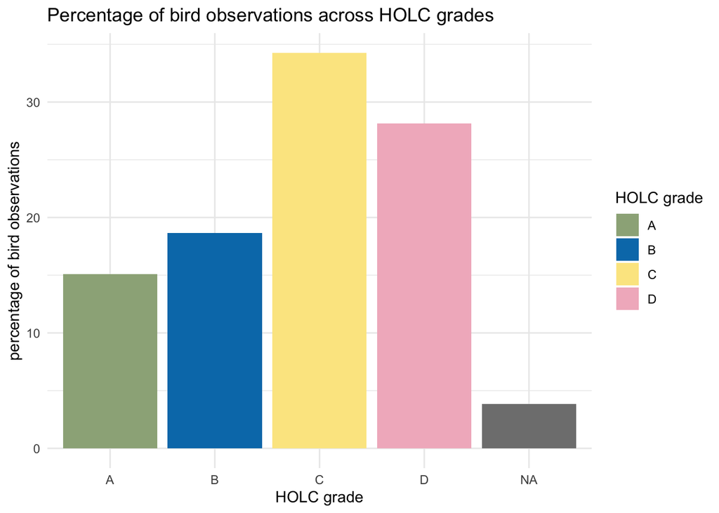

```r
holc_colors <- c(
  "A" = "#9CAF88",
  "B" = "#007BB8",
  "C" = "#FBE790",
  "D" = "#F2B8C6"
)

ggplot(bird_redlining_2022, aes(x = grade, y = percentage, fill = grade))+
  geom_bar(stat = "identity")+
  scale_fill_manual(values = holc_colors)+
  labs( x = "HOLC grade", y = "percentage of bird observations", fill = "HOLC grade", title = "Percentage of bird observations across HOLC grades")+
  theme_minimal()
```

#### Is this what we expected ??

These results were very surprising to me. After reading *Bird Biodiversity Reports Reflect Citie’s Redlined Past,* I expected HOLC grades A and B to have a far greater percentage of bird observations then grades C and D. The article mentions how crowd-sourced bird watching data comes from White neighborhoods that are likely to reside in A or B HOLC grades. The article puts forth a study that looks into bird observations among the four different HOLC grades from 1932 to 2022. Their study finds a larger percentage of bird observations to be from HOLC grade A than any other HOLC grade, in Los Angeles. This contradicts the plot above significantly. The main difference in this plot above and the one put forth in the article is the time period observed. This bar plot looks only at 2022, while the other spans nearly 100 years. Perhaps there has been lasting effects of COVID 19 that have caused community members in lower HOLC grades to spend more time outside looking at birds.**

[^1]: Gee, G. C. (2008). A multilevel analysis of the relationship between institutional and individual racial discrimination and health status. American journal of public health, 98(Supplement_1), S48-S56.
[^2]: Nardone, A., Rudolph, K. E., Morello-Frosch, R., & Casey, J. A. (2021). Redlines and greenspace: the relationship between historical redlining and 2010 greenspace across the United States. Environmental health perspectives, 129(1), 017006.
[^3]: Hoffman, J. S., Shandas, V., & Pendleton, N. (2020). The effects of historical housing policies on resident exposure to intra-urban heat: a study of 108 US urban areas. Climate, 8(1), 12.
[^4]: Robert K. Nelson, LaDale Winling, Richard Marciano, Nathan Connolly, et al., “Mapping Inequality,” American Panorama, ed. Robert K. Nelson and Edward L. Ayers, accessed October 17, 2023, https://dsl.richmond.edu/panorama/redlining/
[^5]: Ellis-Soto, D., Chapman, M., & Locke, D. H. (2023). Historical redlining is associated with increasing geographical disparities in bird biodiversity sampling in the United States. Nature Human Behaviour, 1-9.